# Reproducible Research: Peer Assessment 1

## SETUP

```r
knitr::opts_chunk$set(echo = TRUE)
```

## Loading and preprocessing the data

Load the data (i.e. read.csv())

```r
if(!file.exists("repdata%2Fdata%2Factivity.zip") | !file.exists("activity.csv") )
{
        fileUrl <- "https://d396qusza40orc.cloudfront.net/repdata%2Fdata%2Factivity.zip"
        download.file(fileUrl,destfile="repdata%2Fdata%2Factivity.zip")
        unzip(zipfile="repdata%2Fdata%2Factivity.zip",exdir=".")
}

activity <- read.csv("activity.csv", header = T)
head(activity)
```

```
##   steps       date interval
## 1    NA 2012-10-01        0
## 2    NA 2012-10-01        5
## 3    NA 2012-10-01       10
## 4    NA 2012-10-01       15
## 5    NA 2012-10-01       20
## 6    NA 2012-10-01       25
```

Process/transform the data (if necessary) into a format suitable for your analysis

```r
#no processing
```

## What is mean total number of steps taken per day?

For this part of the assignment, you can ignore the missing values in the dataset.

#### Make a histogram of the total number of steps taken each day

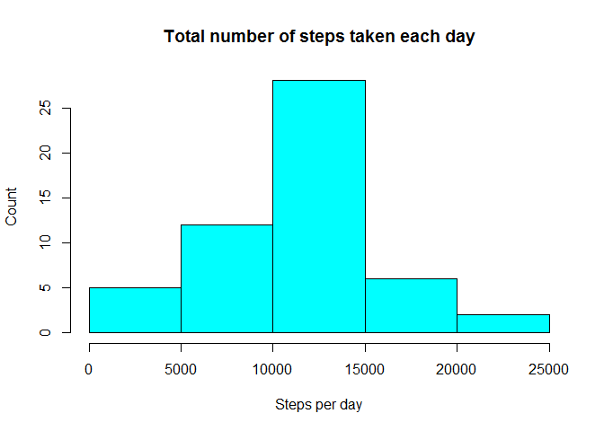

```r
# split per day
stepsPerDay <- split(activity$steps, activity$date)
TotalStepsPerDay <- sapply(stepsPerDay, sum)

# make histogram
hist(TotalStepsPerDay,
     xlab="Steps per day",
     ylab="Count",
     main="Total number of steps taken each day",
     col=5)
```

#### Calculate and report the mean and median total number of steps taken per day

```r
# calculate mean and median
meanTotalSteps <- prettyNum(mean(TotalStepsPerDay, na.rm = TRUE), scientific=FALSE)
medianTotalSteps <- prettyNum(median(TotalStepsPerDay, na.rm = TRUE), scientific=FALSE)
```

The mean total number of steps taken per day are 10766.19. The median total number of steps taken per day are 10765.

## What is the average daily activity pattern?

#### Make a time series plot (i.e. type = “l”) of the 5-minute interval (x-axis) and the average number of steps taken, averaged across all days (y-axis)

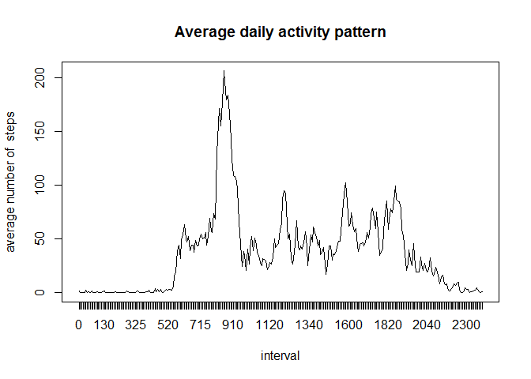

```r
stepsPerInterval <- split(activity$steps, activity$interval)
MeanStepsPerInterval <- sapply(stepsPerInterval, mean, na.rm = TRUE)
intervals <- factor(unique(activity$interval))

# making the plot
plot(intervals, MeanStepsPerInterval, lty = 0,  xlab = "interval", ylab = "average number of  steps", main = "Average daily activity pattern")
# adding lines
lines(intervals, MeanStepsPerInterval, lty = 1, lwd = 1, col = "black")
```

#### Which 5-minute interval, on average across all the days in the dataset, contains the maximum number of steps?

```r
MaxSteps <- max(MeanStepsPerInterval)
MaxInterval <- intervals[MeanStepsPerInterval == MaxSteps]
```

The interval with the maximum average number of steps is interval 835.

## Imputing missing values

Note that there are a number of days/intervals where there are missing values (coded as NA). The presence of missing days may introduce bias into some calculations or summaries of the data.

#### Calculate and report the total number of missing values in the dataset (i.e. the total number of rows with NAs)

```r
missingValues <- sum(is.na(activity$steps)) + sum(is.na(activity$date)) + sum(is.na(activity$interval))
```

There are 2304 missing values in the dataset.

### Devise a strategy for filling in all of the missing values in the dataset. The strategy does not need to be sophisticated. For example, you could use the mean/median for that day, or the mean for that 5-minute interval, etc.

My strategy will be to fill eacht missing value with the overall average number of steps per interval.

### Create a new dataset that is equal to the original dataset but with the missing data filled in.

```r
## new dataframe, to keep the original untouched
imputed <- activity

## Any steps value that is NA, is filled with the overall mean number of steps per interval
missingSteps <- is.na(imputed$steps)
imputed$steps[missingSteps] <- mean(activity$steps, na.rm = TRUE)
missingValuesImputed <- sum(is.na(imputed$steps)) + sum(is.na(imputed$date)) + sum(is.na(imputed$interval))
```

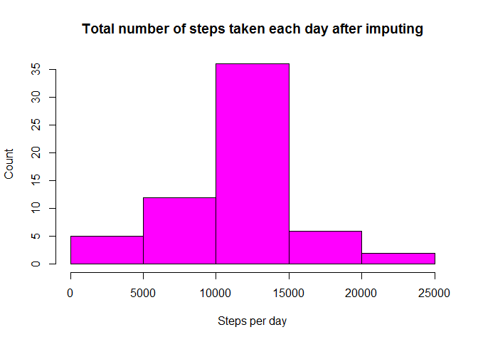

```r
# split per day
imputedStepsPerDay <- split(imputed$steps, imputed$date)
imputedTotalStepsPerDay <- sapply(imputedStepsPerDay, sum)

# make histogram
hist(imputedTotalStepsPerDay,
     xlab="Steps per day",
     ylab="Count",
     main="Total number of steps taken each day after imputing",
     col=6)
```

#### Calculate and report the mean and median total number of steps taken per day

```r
# calculate mean and median
imputedMeanTotalSteps <- prettyNum(mean(imputedTotalStepsPerDay, na.rm = TRUE), scientific=FALSE)
imputedMedianTotalSteps <- prettyNum(median(imputedTotalStepsPerDay, na.rm = TRUE), scientific=FALSE)
```

After imputing the mean total number of steps taken per day are 10766.19. The median total number of steps taken per day are 10766.19.

## Are there differences in activity patterns between weekdays and weekends?

#### Create a new factor variable in the dataset with two levels – “weekday” and “weekend” indicating whether a given date is a weekday or weekend day.

#### Make a panel plot containing a time series plot (i.e. type = “l”) of the 5-minute interval (x-axis) and the average number of steps taken, averaged across all weekday days or weekend days (y-axis). See the README file in the GitHub repository to see an example of what this plot should look like using simulated data.

```r
# Determining weekenddays eand weekdays - weekenddays in dutch are "zaterdag"  and "zondag"
imputed$dayName <- weekdays(as.Date(imputed$date))
imputed$weekend <- ifelse(imputed$dayName%in% c("zaterdag", "zondag"), TRUE, FALSE)
```

#### Make a panel plot containing a time series plot (i.e. type = “l”) of the 5-minute interval (x-axis) and the average number of steps taken, averaged across all weekday days or weekend days (y-axis). See the README file in the GitHub repository to see an example of what this plot should look like using simulated data.

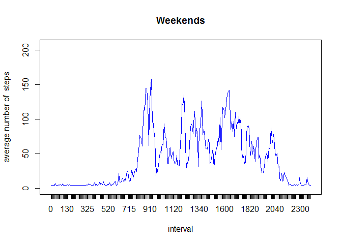

```r
# Weekend
weekend <- imputed[imputed$weekend == TRUE,]
weekendImputedStepsPerInterval <- split(weekend$steps, weekend$interval)
weekendImputedMeanStepsPerInterval <- sapply(weekendImputedStepsPerInterval, mean, na.rm = TRUE)
weekendImputedIntervals <- factor(unique(weekend$interval))

# Weekdays
week <- imputed[imputed$weekend == FALSE,]
weekImputedStepsPerInterval <- split(week$steps, week$interval)
weekImputedMeanStepsPerInterval <- sapply(weekImputedStepsPerInterval, mean, na.rm = TRUE)
weekImputedIntervals <- factor(unique(week$interval))

# building the plot weekenddays
# original layout
plot(intervals, MeanStepsPerInterval, lty = 0,  xlab = "interval", ylab = "average number of  steps", main = "Weekends")
# adding lines
lines(weekendImputedIntervals, weekendImputedMeanStepsPerInterval, lty = 1, lwd = 1, col = "blue")
```

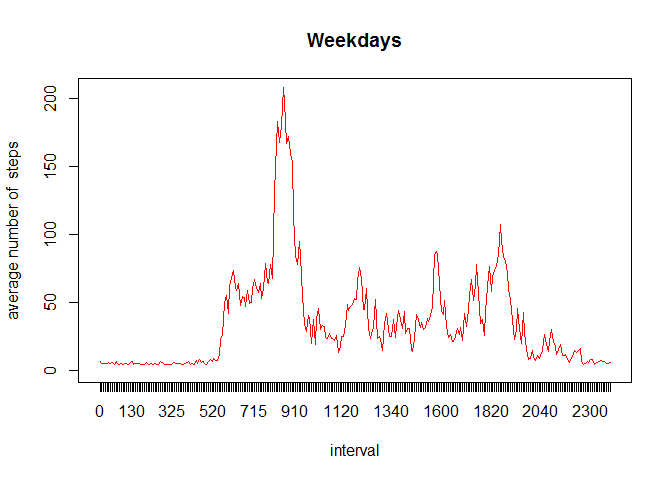

```r
# building the plot weekdays
# original layout
plot(intervals, MeanStepsPerInterval, lty = 0,  xlab = "interval", ylab = "average number of  steps", main = "Weekdays")
# adding lines
lines(weekImputedIntervals, weekImputedMeanStepsPerInterval, lty = 1, lwd = 1, col = "red")
```

```r
# adding legend
```

As extra I made one plot with 2 lines (one for weekend and one for weekdays. This makes it easier to compare the patterns.

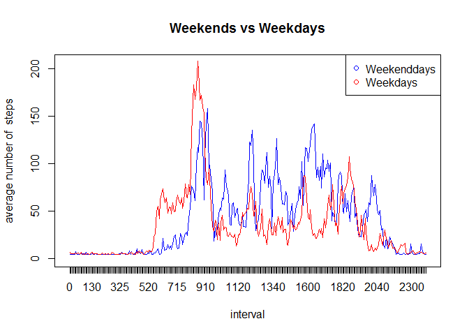

```r
# building the plot
# original layout
plot(intervals, MeanStepsPerInterval, lty = 0,  xlab = "interval", ylab = "average number of  steps", main = "Weekends vs Weekdays")
# adding lines
lines(weekendImputedIntervals, weekendImputedMeanStepsPerInterval, lty = 1, lwd = 1, col = "blue")
lines(weekImputedIntervals, weekImputedMeanStepsPerInterval, lty = 1, lwd = 1, col = "red")
# adding legend
legend("topright", pch = 1, col = c("blue", "red"), legend = c("Weekenddays", "Weekdays"))
```

YES, the pattern in the weekend differs from the pattern in the workingweekdays.